# models

## In this document we compare 5 different models on their

## 1. important variables

## 2. training set sensitivity

## 3. test set sensitivity

## 4. test set auc

### you can scroll to bottom to check `6. comparison`

```r
library(data.table)
library(dplyr)
library(ROCR)
library(leaps)
library(caret)
library(caTools)
library(tree)
```

```r
setwd('./data/')
```

```r
df = readRDS('df_afterKS.rds')
train = 1:941685
traindf = df[train,]
testdf = df[-train,]
```

```r
traindf1 = traindf%>%
  filter(is_attributed ==1)

traindf0 = traindf%>%
  filter(is_attributed == 0)

set.seed(222)
sample0 = sample(1:938452,7544)
traindf_pick0 = traindf0[sample0,]

data = rbind(traindf_pick0,traindf1)
```

```r
mean(data$is_attributed)
```

0.299990720979865

```r
ncol(data)
```

31

```r
names(data)
```

1. 'channelAttrib'

2. 'appAttrib'

3. 'app60s'

4. 'app30s'

5. 'app10s'

6. 'app3s'

7. 'appIp10s'

8. 'appIp3s'

9. 'app1s'

10. 'appOs10s'

11. 'appOs3s'

12. 'channel60s'

13. 'channel30s'

14. 'channelIp10s'

15. 'channel10s'

16. 'channelIp3s'

17. 'channelOs10s'

18. 'channel3s'

19. 'channelOs3s'

20. 'channel1s'

21. 'appChannel3s'

22. 'appChannel10s'

23. 'appDevice3s'

24. 'appDevice10s'

25. 'channelApp10s'

26. 'ipApp10s'

27. 'ipChannel10s'

28. 'ip10s'

29. 'ip30s'

30. 'ip60s'

31. 'is_attributed'

```r
bic_train = read.csv('bic_train.csv')[,-1]
bic_test = read.csv('bic_test.csv')[,-1]
bic_train_c = read.csv('bic_train.csv')[,-1]
bic_test_c = read.csv('bic_test.csv')[,-1]
```

```r
bic_train_c$is_attributed = as.factor(ifelse(bic_train_c$is_attributed == 1, "Yes", "No"))
bic_test_c$is_attributed = as.factor(ifelse(bic_test_c$is_attributed == 1, "Yes", "No"))
```

# 1. Linear Regression

### training sensitivity: 0.8392

### test sensitivity: 0.8664

### test auc: 0.9231

```r
m1 = lm(is_attributed~.,bic_train)
summary(m1)
```

```
Call:
lm(formula = is_attributed ~ ., data = bic_train)

Residuals:
     Min       1Q   Median       3Q      Max
-1.05961 -0.11248 -0.03263  0.04592  1.14096

Coefficients:
                Estimate Std. Error t value Pr(>|t|)
(Intercept)    7.539e-01  1.410e-02  53.482  < 2e-16 ***
channelAttrib  4.465e-01  2.765e-02  16.149  < 2e-16 ***
appAttrib      2.280e-01  2.015e-02  11.311  < 2e-16 ***
app1s          1.632e-04  4.695e-05   3.475 0.000512 ***
appOs10s      -1.221e-02  3.974e-04 -30.730  < 2e-16 ***
channelIp10s   2.121e-04  1.941e-05  10.922  < 2e-16 ***
channelOs10s  -7.620e-03  8.364e-04  -9.110  < 2e-16 ***
channelOs3s   -4.213e-03  1.044e-03  -4.036 5.48e-05 ***
appDevice10s   1.974e-02  1.966e-03  10.043  < 2e-16 ***
channelApp10s  2.712e-02  1.760e-03  15.409  < 2e-16 ***
ipApp10s      -2.700e-02  3.125e-03  -8.642  < 2e-16 ***
ip10s          5.840e-03  1.531e-03   3.814 0.000138 ***
---
Signif. codes:  0 ‘***’ 0.001 ‘**’ 0.01 ‘*’ 0.05 ‘.’ 0.1 ‘ ’ 1

Residual standard error: 0.2525 on 10765 degrees of freedom
Multiple R-squared:  0.6967,	Adjusted R-squared:  0.6964
F-statistic:  2248 on 11 and 10765 DF,  p-value: < 2.2e-16
```

```r
m1_control = trainControl(method = "repeatedcv",
                          number = 5,
                          repeats = 5)
```

```r
m1_train = train(is_attributed ~ .,
                 data = bic_train,
                 method = "lm",
                 trControl = m1_control)
```

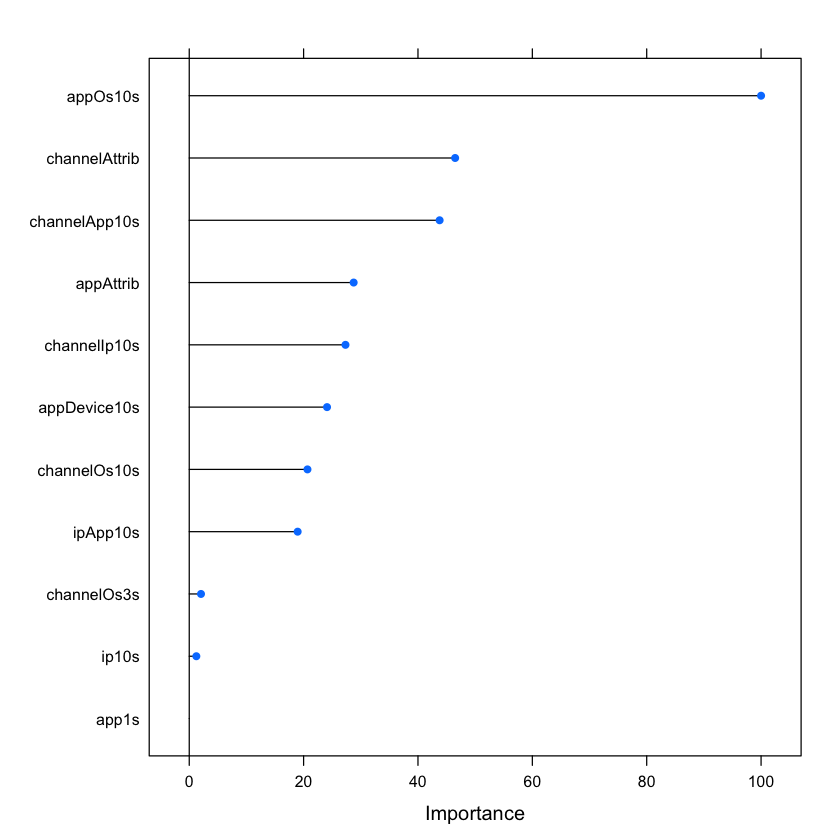

```r
plot(varImp(m1_train))
```

```r
m1_train
```

```
Linear Regression

10777 samples
   11 predictor

No pre-processing
Resampling: Cross-Validated (5 fold, repeated 5 times)
Summary of sample sizes: 8622, 8622, 8621, 8621, 8622, 8621, ...
Resampling results:

  RMSE       Rsquared   MAE
  0.2526674  0.6959753  0.1543308

Tuning parameter 'intercept' was held constant at a value of TRUE
```

```r
m1_pred_train = predict(m1_train, bic_train)
m1_result_train = ifelse(m1_pred_train>0.5,1,0)
```

```r
confusionMatrix(m1_result_train, bic_train$is_attributed,positive = '1')
```

```
Confusion Matrix and Statistics

          Reference
Prediction    0    1
         0 7401  520
         1  143 2713

               Accuracy : 0.9385
                 95% CI : (0.9338, 0.9429)
    No Information Rate : 0.7
    P-Value [Acc > NIR] : < 2.2e-16

                  Kappa : 0.8485
 Mcnemar's Test P-Value : < 2.2e-16

            Sensitivity : 0.8392
            Specificity : 0.9810
         Pos Pred Value : 0.9499
         Neg Pred Value : 0.9344
             Prevalence : 0.3000
         Detection Rate : 0.2517
   Detection Prevalence : 0.2650
      Balanced Accuracy : 0.9101

       'Positive' Class : 1
```

```r
m1_pred_test = predict(m1_train, bic_test)
m1_result_test = ifelse(m1_pred_test>0.5,1,0)
```

```r
confusionMatrix(m1_result_test, bic_test$is_attributed,positive = '1')
```

```
Confusion Matrix and Statistics

          Reference
Prediction      0      1
         0 488083    245
         1  10083   1589

               Accuracy : 0.9793
                 95% CI : (0.9789, 0.9797)
    No Information Rate : 0.9963
    P-Value [Acc > NIR] : 1

                  Kappa : 0.2304
 Mcnemar's Test P-Value : <2e-16

            Sensitivity : 0.866412
            Specificity : 0.979760
         Pos Pred Value : 0.136138
         Neg Pred Value : 0.999498
             Prevalence : 0.003668
         Detection Rate : 0.003178
   Detection Prevalence : 0.023344
      Balanced Accuracy : 0.923086

       'Positive' Class : 1
```

| 0 vs. 1 | 0.923086 |
| --- | --- |

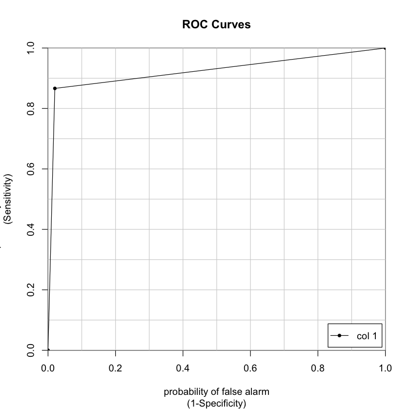

```r
colAUC(m1_result_test, bic_test$is_attributed, plotROC = TRUE)
```

## 2. Logistic Regression

### training sensitivity: 0.8423

### test sensitivity: 0.8604

### test auc: 0.9552

### here I tested whether setting AUC instead of accuracy as optimization goal will change the result, the answer is no

```r
m2_control = trainControl(method = "repeatedcv",
                          number = 5,repeats = 5,
                          classProbs = TRUE ,
                          summaryFunction = twoClassSummary
                          )# IMPORTANT!
m2_control_nroc = trainControl(method = "repeatedcv",
                          number = 5,repeats = 5,
                          classProbs = TRUE
                          )
```

```r
m2_train_nroc = train(is_attributed~.,
                 data = bic_train_c,
                 method = "glm",
                 family = "binomial",
                 trControl = m2_control_nroc)
m2_train_nroc
```

```
Generalized Linear Model

10777 samples
   11 predictor
    2 classes: 'No', 'Yes'

No pre-processing
Resampling: Cross-Validated (5 fold, repeated 5 times)
Summary of sample sizes: 8621, 8621, 8621, 8623, 8622, 8622, ...
Resampling results:

  Accuracy   Kappa
  0.9451243  0.8641501
```

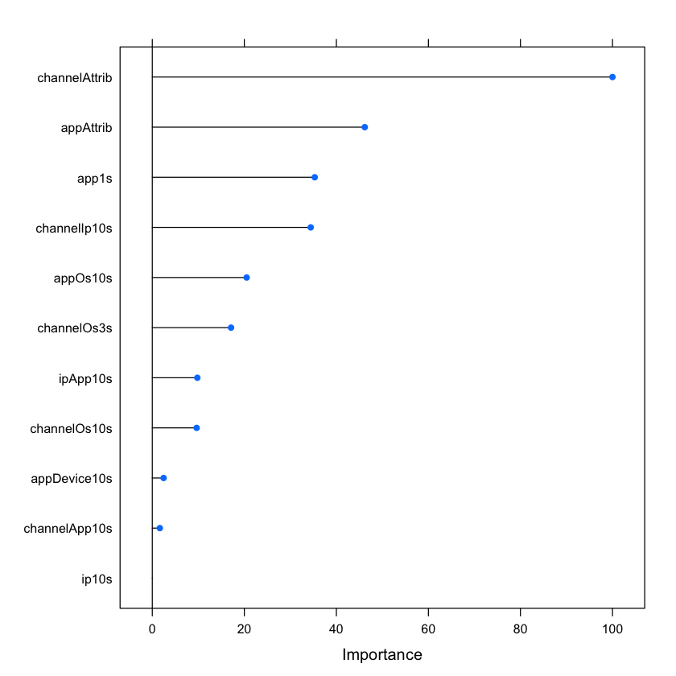

```r
plot(varImp(m2_train_nroc))
```

```r
m2_pred_nroc_train = predict(m2_train_nroc, bic_train_c)
confusionMatrix(m2_pred_nroc_train, bic_train_c$is_attributed,positive = 'Yes')
```

```
Confusion Matrix and Statistics

          Reference
Prediction   No  Yes
       No  7473  510
       Yes   71 2723

               Accuracy : 0.9461
                 95% CI : (0.9417, 0.9503)
    No Information Rate : 0.7
    P-Value [Acc > NIR] : < 2.2e-16

                  Kappa : 0.8665
 Mcnemar's Test P-Value : < 2.2e-16

            Sensitivity : 0.8423
            Specificity : 0.9906
         Pos Pred Value : 0.9746
         Neg Pred Value : 0.9361
             Prevalence : 0.3000
         Detection Rate : 0.2527
   Detection Prevalence : 0.2593
      Balanced Accuracy : 0.9164

       'Positive' Class : Yes
```

```r
m2_pred_nroc = predict(m2_train_nroc, bic_test_c)
confusionMatrix(m2_pred_nroc, bic_test$is_attributed,positive = 'Yes')
```

```
Confusion Matrix and Statistics

          Reference
Prediction     No    Yes
       No  492366    256
       Yes   5800   1578

               Accuracy : 0.9879
                 95% CI : (0.9876, 0.9882)
    No Information Rate : 0.9963
    P-Value [Acc > NIR] : 1

                  Kappa : 0.3387
 Mcnemar's Test P-Value : <2e-16

            Sensitivity : 0.860414
            Specificity : 0.988357
         Pos Pred Value : 0.213879
         Neg Pred Value : 0.999480
             Prevalence : 0.003668
         Detection Rate : 0.003156
   Detection Prevalence : 0.014756
      Balanced Accuracy : 0.924386

       'Positive' Class : Yes
```

```r
m2_train = train(is_attributed~.,
                 data = bic_train_c,
                 method = "glm",
                 family = "binomial",
                 trControl = m2_control,
                 metric = "ROC")
m2_train
```

```
Generalized Linear Model

10777 samples
   11 predictor
    2 classes: 'No', 'Yes'

No pre-processing
Resampling: Cross-Validated (5 fold, repeated 5 times)
Summary of sample sizes: 8622, 8622, 8622, 8621, 8621, 8621, ...
Resampling results:

  ROC        Sens      Spec
  0.9485861  0.989422  0.8421892
```

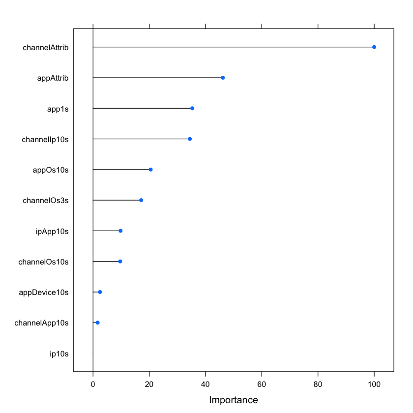

```r
plot(varImp(m2_train))
```

```r
m2_pred_train = predict(m2_train, bic_train_c)
confusionMatrix(m2_pred_train, bic_train_c$is_attributed,positive = 'Yes')
```

```
Confusion Matrix and Statistics

          Reference
Prediction   No  Yes
       No  7473  510
       Yes   71 2723

               Accuracy : 0.9461
                 95% CI : (0.9417, 0.9503)
    No Information Rate : 0.7
    P-Value [Acc > NIR] : < 2.2e-16

                  Kappa : 0.8665
 Mcnemar's Test P-Value : < 2.2e-16

            Sensitivity : 0.8423
            Specificity : 0.9906
         Pos Pred Value : 0.9746
         Neg Pred Value : 0.9361
             Prevalence : 0.3000
         Detection Rate : 0.2527
   Detection Prevalence : 0.2593
      Balanced Accuracy : 0.9164

       'Positive' Class : Yes
```

```r
m2_pred = predict(m2_train, bic_test_c)
confusionMatrix(m2_pred, bic_test$is_attributed,positive = 'Yes')
```

```
Confusion Matrix and Statistics

          Reference
Prediction     No    Yes
       No  492366    256
       Yes   5800   1578

               Accuracy : 0.9879
                 95% CI : (0.9876, 0.9882)
    No Information Rate : 0.9963
    P-Value [Acc > NIR] : 1

                  Kappa : 0.3387
 Mcnemar's Test P-Value : <2e-16

            Sensitivity : 0.860414
            Specificity : 0.988357
         Pos Pred Value : 0.213879
         Neg Pred Value : 0.999480
             Prevalence : 0.003668
         Detection Rate : 0.003156
   Detection Prevalence : 0.014756
      Balanced Accuracy : 0.924386

       'Positive' Class : Yes
```

```r
m2_pred_p = predict(m2_train, bic_test_c,type = "prob")
```

|  | No | Yes |
| --- | --- | --- |
| No vs. Yes | 0.9551997 | 0.9551997 |

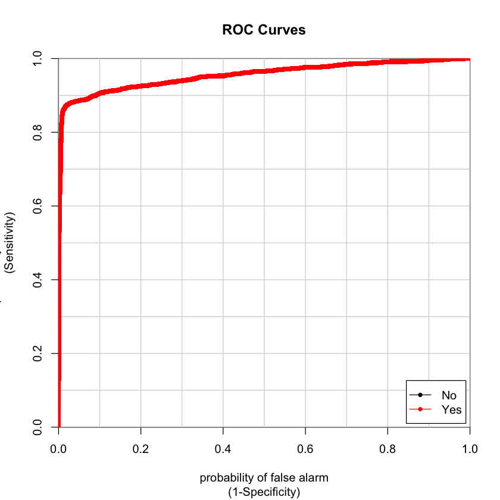

```r
#https://www.rdocumentation.org/packages/caTools/versions/1.17.1/topics/colAUC
colAUC(m2_pred_p, bic_test_c$is_attributed, plotROC = TRUE)
```

## 3. Decision Tree

### training sensitivity: 0.8466

### test sensitivity: 0.8648

### test auc: 0.9546

```r
score.train = ifelse(bic_train$is_attributed == 1, "Yes", "No")
score.test = ifelse(bic_test$is_attributed == 1, "Yes", "No")
download.train = data.frame(bic_train,score.train)
download.test = data.frame(bic_test,score.test)
tree_train = tree(score.train~.-is_attributed,download.train)
summary(tree_train)
```

```
Classification tree:
tree(formula = score.train ~ . - is_attributed, data = download.train)
Variables actually used in tree construction:
[1] "channelAttrib" "appAttrib"
Number of terminal nodes:  4
Residual mean deviance:  0.3644 = 3926 / 10770
Misclassification error rate: 0.05549 = 598 / 10777
```

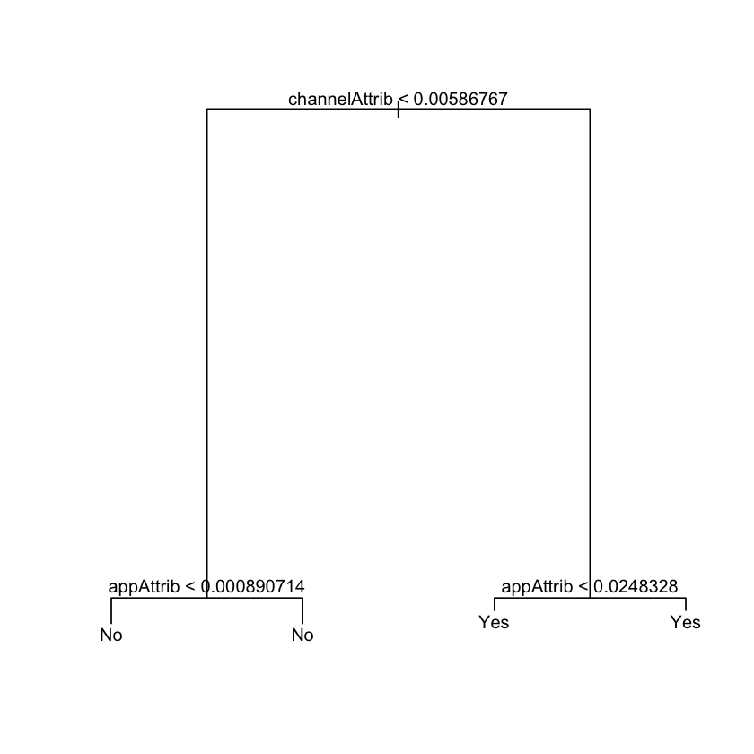

```r
plot(tree_train)
text(tree_train,pretty = 0)
```

```r
tree_pred_train=predict(tree_train,download.train,type = "class")
confusionMatrix(tree_pred_train, bic_train_c$is_attributed,positive = 'Yes')
```

```
Confusion Matrix and Statistics

          Reference
Prediction   No  Yes
       No  7442  496
       Yes  102 2737

               Accuracy : 0.9445
                 95% CI : (0.94, 0.9488)
    No Information Rate : 0.7
    P-Value [Acc > NIR] : < 2.2e-16

                  Kappa : 0.8631
 Mcnemar's Test P-Value : < 2.2e-16

            Sensitivity : 0.8466
            Specificity : 0.9865
         Pos Pred Value : 0.9641
         Neg Pred Value : 0.9375
             Prevalence : 0.3000
         Detection Rate : 0.2540
   Detection Prevalence : 0.2634
      Balanced Accuracy : 0.9165

       'Positive' Class : Yes
```

```r
tree_pred=predict(tree_train,download.test,type = "class")
confusionMatrix(tree_pred, bic_test_c$is_attributed,positive = 'Yes')
```

```
Confusion Matrix and Statistics

          Reference
Prediction     No    Yes
       No  490566    248
       Yes   7600   1586

               Accuracy : 0.9843
                 95% CI : (0.984, 0.9846)
    No Information Rate : 0.9963
    P-Value [Acc > NIR] : 1

                  Kappa : 0.2835
 Mcnemar's Test P-Value : <2e-16

            Sensitivity : 0.864776
            Specificity : 0.984744
         Pos Pred Value : 0.172654
         Neg Pred Value : 0.999495
             Prevalence : 0.003668
         Detection Rate : 0.003172
   Detection Prevalence : 0.018372
      Balanced Accuracy : 0.924760

       'Positive' Class : Yes
```

|  | No | Yes |
| --- | --- | --- |
| 0 vs. 1 | 0.9546324 | 0.9546324 |

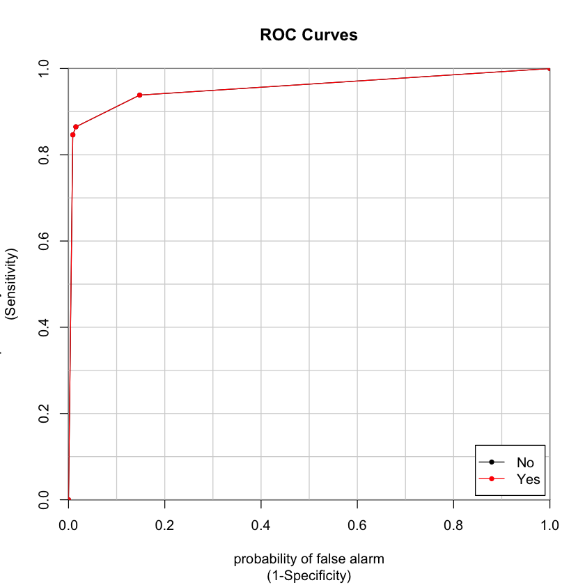

```r
tree_pred_p=predict(tree_train,download.test,type = "vector")
colAUC(tree_pred_p, bic_test$is_attributed, plotROC = TRUE)
```

## 4. Random Forest

### training sensitivity: 1.00

### test sensitivity: 0.8626

### test auc: 0.9636

```r
m4_control = trainControl(method = "repeatedcv",
                          number = 5,repeats = 5,
                          classProbs = TRUE ,
                          summaryFunction = twoClassSummary,
                          search = "grid")
```

```r
length(names(bic_train))
```

12

```r
m4_grid = expand.grid(mtry = 4:6)
```

```r
m4_grid
```

| mtry |
| --- |
| 4 |
| 5 |
| 6 |

```r
m4_train = train(is_attributed~.,
                 data = bic_train_c,
                 method = "rf",
                 trControl = m4_control,
                 verbose = FALSE,
                 tuneGrid = m4_grid,
                metric = "ROC")
```

```r
m4_train
```

```
Random Forest

10777 samples
   11 predictor
    2 classes: 'No', 'Yes'

No pre-processing
Resampling: Cross-Validated (5 fold, repeated 5 times)
Summary of sample sizes: 8622, 8621, 8622, 8622, 8621, 8622, ...
Resampling results across tuning parameters:

  mtry  ROC        Sens       Spec
  4     0.9568332  0.9861610  0.8583981
  5     0.9566425  0.9857634  0.8581501
  6     0.9566718  0.9855778  0.8579646

ROC was used to select the optimal model using  the largest value.
The final value used for the model was mtry = 4.
```

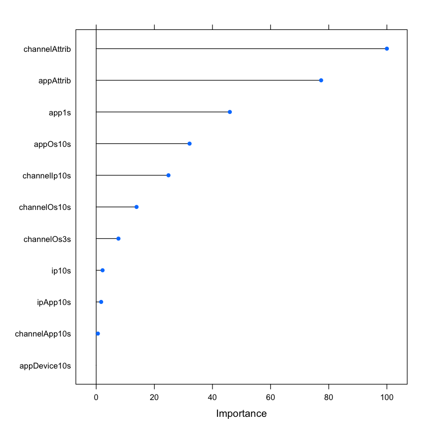

```r
plot(varImp(m4_train))
```

```r
m4_pred_train = predict(m4_train, bic_train_c)
confusionMatrix(m4_pred_train, bic_train_c$is_attributed,positive = 'Yes')
```

```
Confusion Matrix and Statistics

          Reference
Prediction   No  Yes
       No  7544    0
       Yes    0 3233

               Accuracy : 1
                 95% CI : (0.9997, 1)
    No Information Rate : 0.7
    P-Value [Acc > NIR] : < 2.2e-16

                  Kappa : 1
 Mcnemar's Test P-Value : NA

            Sensitivity : 1.0
            Specificity : 1.0
         Pos Pred Value : 1.0
         Neg Pred Value : 1.0
             Prevalence : 0.3
         Detection Rate : 0.3
   Detection Prevalence : 0.3
      Balanced Accuracy : 1.0

       'Positive' Class : Yes
```

```r
m4_pred = predict(m4_train, bic_test_c)
confusionMatrix(m5_pred, bic_test_c$is_attributed,positive = 'Yes')
```

```
Confusion Matrix and Statistics

          Reference
Prediction     No    Yes
       No  493145    252
       Yes   5021   1582

               Accuracy : 0.9895
                 95% CI : (0.9892, 0.9897)
    No Information Rate : 0.9963
    P-Value [Acc > NIR] : 1

                  Kappa : 0.3714
 Mcnemar's Test P-Value : <2e-16

            Sensitivity : 0.862595
            Specificity : 0.989921
         Pos Pred Value : 0.239588
         Neg Pred Value : 0.999489
             Prevalence : 0.003668
         Detection Rate : 0.003164
   Detection Prevalence : 0.013206
      Balanced Accuracy : 0.926258

       'Positive' Class : Yes
```

|  | No | Yes |
| --- | --- | --- |
| 0 vs. 1 | 0.9636197 | 0.9636197 |

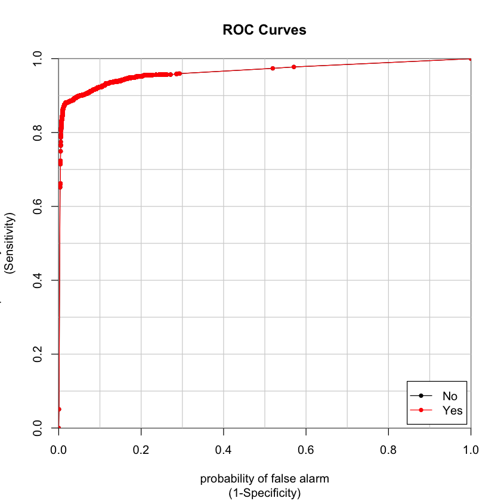

```r
m4_pred_p = predict(m4_train, bic_test_c,type = "prob")
colAUC(m5_pred_p, bic_test$is_attributed, plotROC = TRUE)
```

## 5. Gradient Boosting Tree

### training sensitivity: 0.8432

### test sensitivity: 0.8626

### test auc: 0.9626

```r
m5_control = trainControl(method = "repeatedcv",
                          number = 5,repeats = 5,
                          classProbs = TRUE ,
                          summaryFunction = twoClassSummary,
                          search = "grid")
m5_control_nroc = trainControl(method = "repeatedcv",
                          number = 5,repeats = 5,
                          classProbs = TRUE,
                          search = "grid")
```

```r
m5_grid = expand.grid(interaction.depth = c(1, 5),
                      n.trees = (18:23)*50,
                     shrinkage = 0.001,
                     n.minobsinnode = 20)
```

```r
head(m5_grid)
```

| interaction.depth | n.trees | shrinkage | n.minobsinnode |
| --- | --- | --- | --- |
| 1 | 900 | 0.001 | 20 |
| 5 | 900 | 0.001 | 20 |
| 1 | 950 | 0.001 | 20 |
| 5 | 950 | 0.001 | 20 |
| 1 | 1000 | 0.001 | 20 |
| 5 | 1000 | 0.001 | 20 |

```r
m5_train_nroc = train(is_attributed~.,
                 data = bic_train_c,
                 method = "gbm",
                 distribution = 'bernoulli',
                 trControl = m5_control_nroc,
                 verbose = FALSE,
                 tuneGrid = m5_grid)
```

```r
m5_train_nroc
```

```
Stochastic Gradient Boosting

10777 samples
   11 predictor
    2 classes: 'No', 'Yes'

No pre-processing
Resampling: Cross-Validated (5 fold, repeated 5 times)
Summary of sample sizes: 8622, 8621, 8622, 8622, 8621, 8622, ...
Resampling results across tuning parameters:

  interaction.depth  n.trees  Accuracy   Kappa
  1                   900     0.9434906  0.8594447
  1                   950     0.9434721  0.8594378
  1                  1000     0.9436390  0.8599162
  1                  1050     0.9437504  0.8602357
  1                  1100     0.9438803  0.8605868
  1                  1150     0.9439175  0.8607073
  5                   900     0.9453650  0.8642863
  5                   950     0.9455320  0.8647503
  5                  1000     0.9458846  0.8656762
  5                  1050     0.9459959  0.8659721
  5                  1100     0.9461258  0.8663281
  5                  1150     0.9462558  0.8667041

Tuning parameter 'shrinkage' was held constant at a value of 0.001

Tuning parameter 'n.minobsinnode' was held constant at a value of 20
Accuracy was used to select the optimal model using  the largest value.
The final values used for the model were n.trees = 1150, interaction.depth =
 5, shrinkage = 0.001 and n.minobsinnode = 20.
```

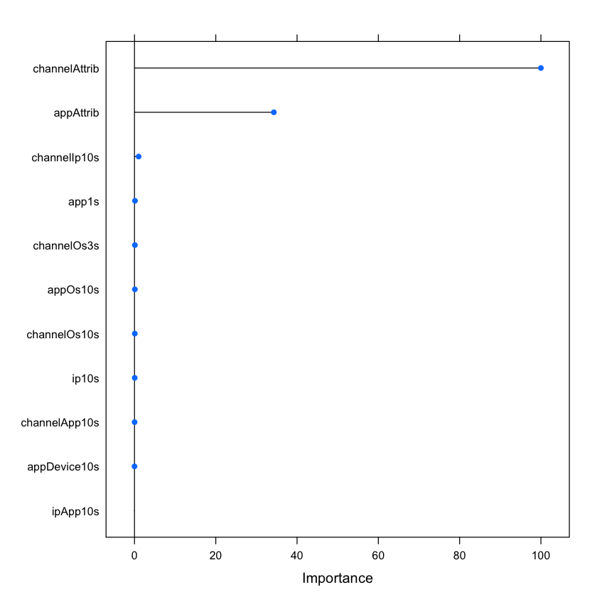

```r
plot(varImp(m5_train_nroc))
```

```r
m5_pred_train_nroc = predict(m5_train_nroc, bic_train_c)
confusionMatrix(m5_pred_train_nroc, bic_train_c$is_attributed,positive = 'Yes')
```

```
Confusion Matrix and Statistics

          Reference
Prediction   No  Yes
       No  7485  507
       Yes   59 2726

               Accuracy : 0.9475
                 95% CI : (0.9431, 0.9516)
    No Information Rate : 0.7
    P-Value [Acc > NIR] : < 2.2e-16

                  Kappa : 0.8698
 Mcnemar's Test P-Value : < 2.2e-16

            Sensitivity : 0.8432
            Specificity : 0.9922
         Pos Pred Value : 0.9788
         Neg Pred Value : 0.9366
             Prevalence : 0.3000
         Detection Rate : 0.2529
   Detection Prevalence : 0.2584
      Balanced Accuracy : 0.9177

       'Positive' Class : Yes
```

```r
m5_pred_nroc = predict(m5_train_nroc, bic_test_c)
confusionMatrix(m5_pred_nroc, bic_test_c$is_attributed,positive = 'Yes')
```

```
Confusion Matrix and Statistics

          Reference
Prediction     No    Yes
       No  493131    252
       Yes   5035   1582

               Accuracy : 0.9894
                 95% CI : (0.9891, 0.9897)
    No Information Rate : 0.9963
    P-Value [Acc > NIR] : 1

                  Kappa : 0.3708
 Mcnemar's Test P-Value : <2e-16

            Sensitivity : 0.862595
            Specificity : 0.989893
         Pos Pred Value : 0.239081
         Neg Pred Value : 0.999489
             Prevalence : 0.003668
         Detection Rate : 0.003164
   Detection Prevalence : 0.013234
      Balanced Accuracy : 0.926244

       'Positive' Class : Yes
```

|  | No | Yes |
| --- | --- | --- |
| 0 vs. 1 | 0.9626353 | 0.9626353 |

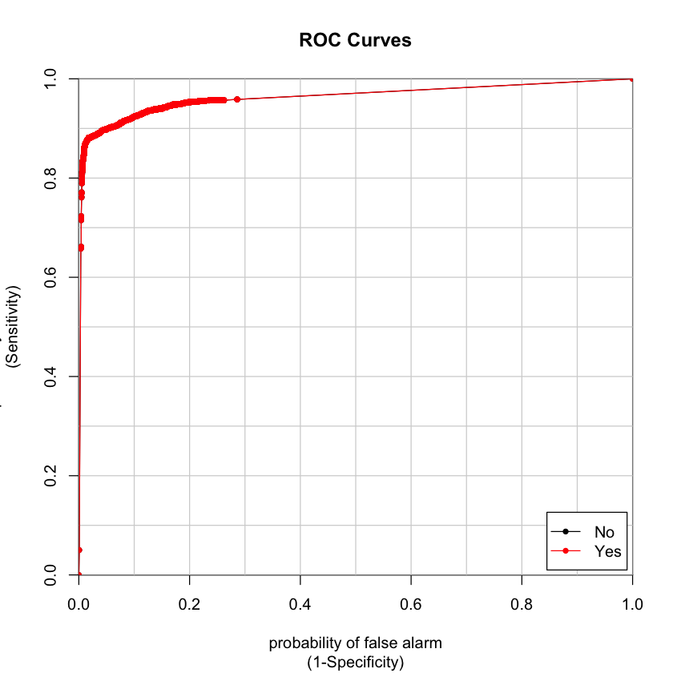

```r
m5_pred_nroc_p = predict(m5_train_nroc, bic_test_c,type = "prob")
colAUC(m5_pred_nroc_p, bic_test$is_attributed, plotROC = TRUE)
```

```r
m5_train = train(is_attributed~.,
                 data = bic_train_c,
                 method = "gbm",
                 distribution = 'bernoulli',
                 trControl = m5_control,
                 verbose = FALSE,
                 tuneGrid = m5_grid,
                 metric = "ROC")
```

```r
m5_train
```

```
Stochastic Gradient Boosting

10777 samples
   11 predictor
    2 classes: 'No', 'Yes'

No pre-processing
Resampling: Cross-Validated (5 fold, repeated 5 times)
Summary of sample sizes: 8621, 8622, 8621, 8622, 8622, 8622, ...
Resampling results across tuning parameters:

  interaction.depth  n.trees  ROC        Sens       Spec
  1                   900     0.9424780  0.9913574  0.8316085
  1                   950     0.9424763  0.9911983  0.8322269
  1                  1000     0.9427367  0.9911718  0.8327221
  1                  1050     0.9428261  0.9909862  0.8335265
  1                  1100     0.9461340  0.9909332  0.8339595
  1                  1150     0.9475575  0.9908006  0.8348256
  5                   900     0.9620953  0.9919406  0.8379189
  5                   950     0.9620725  0.9918611  0.8387229
  5                  1000     0.9622265  0.9917816  0.8392179
  5                  1050     0.9623486  0.9917020  0.8400841
  5                  1100     0.9625039  0.9915960  0.8412598
  5                  1150     0.9625725  0.9914634  0.8419405

Tuning parameter 'shrinkage' was held constant at a value of 0.001

Tuning parameter 'n.minobsinnode' was held constant at a value of 20
ROC was used to select the optimal model using  the largest value.
The final values used for the model were n.trees = 1150, interaction.depth =
 5, shrinkage = 0.001 and n.minobsinnode = 20.
```

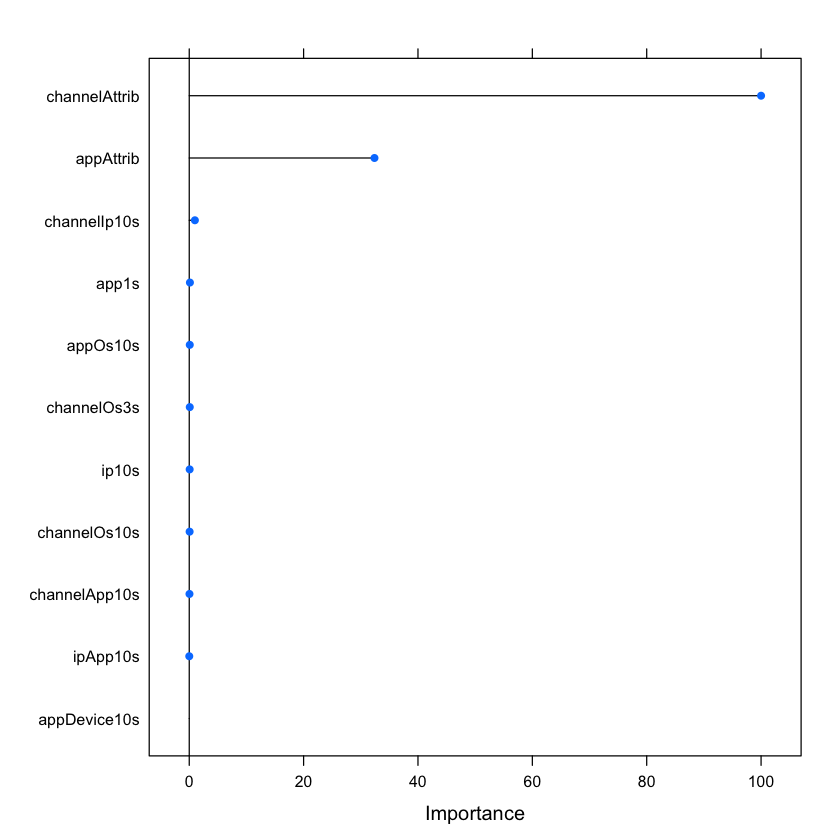

```r
plot(varImp(m5_train))
```

```r
m5_pred_train = predict(m5_train, bic_train_c)
confusionMatrix(m5_pred_train, bic_train_c$is_attributed,positive = 'Yes')
```

```
Confusion Matrix and Statistics

          Reference
Prediction   No  Yes
       No  7485  506
       Yes   59 2727

               Accuracy : 0.9476
                 95% CI : (0.9432, 0.9517)
    No Information Rate : 0.7
    P-Value [Acc > NIR] : < 2.2e-16

                  Kappa : 0.87
 Mcnemar's Test P-Value : < 2.2e-16

            Sensitivity : 0.8435
            Specificity : 0.9922
         Pos Pred Value : 0.9788
         Neg Pred Value : 0.9367
             Prevalence : 0.3000
         Detection Rate : 0.2530
   Detection Prevalence : 0.2585
      Balanced Accuracy : 0.9178

       'Positive' Class : Yes
```

```r
m5_pred = predict(m5_train, bic_test_c)
confusionMatrix(m5_pred, bic_test_c$is_attributed,positive = 'Yes')
```

```
Confusion Matrix and Statistics

          Reference
Prediction     No    Yes
       No  493145    252
       Yes   5021   1582

               Accuracy : 0.9895
                 95% CI : (0.9892, 0.9897)
    No Information Rate : 0.9963
    P-Value [Acc > NIR] : 1

                  Kappa : 0.3714
 Mcnemar's Test P-Value : <2e-16

            Sensitivity : 0.862595
            Specificity : 0.989921
         Pos Pred Value : 0.239588
         Neg Pred Value : 0.999489
             Prevalence : 0.003668
         Detection Rate : 0.003164
   Detection Prevalence : 0.013206
      Balanced Accuracy : 0.926258

       'Positive' Class : Yes
```

|  | No | Yes |
| --- | --- | --- |
| 0 vs. 1 | 0.9636197 | 0.9636197 |

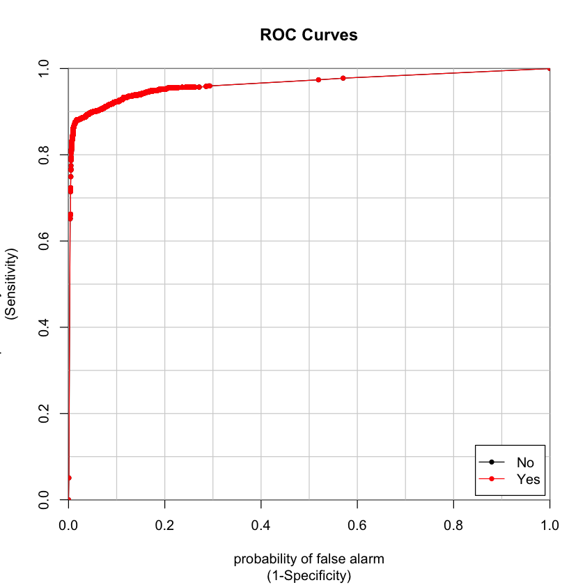

```r
m5_pred_p = predict(m5_train, bic_test_c,type = "prob")
colAUC(m5_pred_p, bic_test$is_attributed, plotROC = TRUE)
```

## 6. Comparison

### 6.1 statistics

```r
#1.
### training sensitivity: 0.8392
### test sensitivity: 0.8664
### test auc: 0.9231
#2.
### training sensitivity: 0.8423
### test sensitivity: 0.8604
### test auc: 0.9552
#3.
### training sensitivity: 0.8466
### test sensitivity: 0.8648
### test auc: 0.9546
#4.
### training sensitivity: 1.00
### test sensitivity: 0.8626
### test auc: 0.9636
#5.
### training sensitivity: 0.8432
### test sensitivity: 0.8626
### test auc: 0.9626
compare_stat =  data.frame(
    statistics = c('training_sensitivity','test_sensitivity','test_auc'),
    linear_regression = c(0.8392,0.8664,0.9231),
    logistic_regression = c(0.8423,0.8604,0.9552),
    decision_tree = c(0.8466,0.8648,0.9546),
    random_forest = c(1.00,0.8626,0.9636),
    gradient_boosted_tree = c(0.8432,0.8626,0.9626)
          )
compare_stat
```

| statistics | linear_regression | logistic_regression | decision_tree | random_forest | gradient_boosted_tree |
| --- | --- | --- | --- | --- | --- |
| training_sensitivity | 0.8392 | 0.8423 | 0.8466 | 1.0000 | 0.8432 |
| test_sensitivity | 0.8664 | 0.8604 | 0.8648 | 0.8626 | 0.8626 |
| test_auc | 0.9231 | 0.9552 | 0.9546 | 0.9636 | 0.9626 |

### Notes

- from above we can see despite showing signs of overfitting, random forest still performs the best in `test auc` (this indicates by tuning we can further improve random forest) (but it takes a long time)
- generally the models perform about the same, around `86%` of downloads will be caught by us

### 6.2 variables

```r
data.frame(
      varImp(m1_train)$importance,
      varImp(m2_train)$importance,
      varImp(m4_train)$importance,
      varImp(m5_train)$importance)
```

|  | Overall | Overall.1 | Overall.2 | Overall.3 |
| --- | --- | --- | --- | --- |
| channelAttrib | 46.499505 | 100.000000 | 100.0000000 | 1.000000e+02 |
| appAttrib | 28.751234 | 46.171722 | 77.3816567 | 3.239315e+01 |
| app1s | 0.000000 | 35.291989 | 45.9712188 | 1.194000e-01 |
| appOs10s | 100.000000 | 20.505228 | 32.1201156 | 9.182497e-02 |
| channelIp10s | 27.323061 | 34.426982 | 24.8652867 | 9.869226e-01 |
| channelOs10s | 20.673596 | 9.640272 | 13.8820394 | 6.597590e-02 |
| channelOs3s | 2.056198 | 17.114948 | 7.6555573 | 9.114827e-02 |
| appDevice10s | 24.097168 | 2.460990 | 0.0000000 | 0.000000e+00 |
| channelApp10s | 43.785043 | 1.637548 | 0.5796503 | 4.131631e-02 |
| ipApp10s | 18.957142 | 9.789368 | 1.7033130 | 4.727522e-03 |
| ip10s | 1.242412 | 0.000000 | 2.1933171 | 7.280207e-02 |

```r
varImp(m1_train)
```

```
lm variable importance

              Overall
appOs10s      100.000
channelAttrib  46.500
channelApp10s  43.785
appAttrib      28.751
channelIp10s   27.323
appDevice10s   24.097
channelOs10s   20.674
ipApp10s       18.957
channelOs3s     2.056
ip10s           1.242
app1s           0.000
```

```r
varImp(m2_train)
```

```
glm variable importance

              Overall
channelAttrib 100.000
appAttrib      46.172
app1s          35.292
channelIp10s   34.427
appOs10s       20.505
channelOs3s    17.115
ipApp10s        9.789
channelOs10s    9.640
appDevice10s    2.461
channelApp10s   1.638
ip10s           0.000
```

```r
summary(tree_train)
```

```
Classification tree:
tree(formula = score.train ~ . - is_attributed, data = download.train)
Variables actually used in tree construction:
[1] "channelAttrib" "appAttrib"
Number of terminal nodes:  4
Residual mean deviance:  0.3644 = 3926 / 10770
Misclassification error rate: 0.05549 = 598 / 10777
```

```r
varImp(m4_train)
```

```
rf variable importance

               Overall
channelAttrib 100.0000
appAttrib      77.3817
app1s          45.9712
appOs10s       32.1201
channelIp10s   24.8653
channelOs10s   13.8820
channelOs3s     7.6556
ip10s           2.1933
ipApp10s        1.7033
channelApp10s   0.5797
appDevice10s    0.0000
```

```r
varImp(m5_train)
```

```
gbm variable importance

                Overall
channelAttrib 1.000e+02
appAttrib     3.239e+01
channelIp10s  9.869e-01
app1s         1.194e-01
appOs10s      9.182e-02
channelOs3s   9.115e-02
ip10s         7.280e-02
channelOs10s  6.598e-02
channelApp10s 4.132e-02
ipApp10s      4.728e-03
appDevice10s  0.000e+00
```

### Note before notes

- app: app id for marketing
- channel: channel id of mobile ad publisher

### Notes

- from above we can discover that `channelAttrib` and `appAttrib` are usually (model 2,3,4,5) the most important predictors, actually in model 3, 5 these two are the only ones matter
- linear regression gave us a strange set of variable importance
- to interpret this, we can say specific `channel` or `app` are the most important indicator of whether a click will turn into download, and `channel` is more important than `app`
- thus, deciding where to put your ad (`channel`) is even more important than your product (`app`)
- `app1s` is probably the third important variable, we can interpret this as a burst of clicks, which may indicate trying to spot robots (and ignore them?) is useful for us to locate potential downloads